# Assignment_Wk3_2026-09-29

Shivoan Balakumar

2026-09-29

# Assignment Week 3 - BIOS640

##Exercise 1

Install Packages

Import Data

```r
#import nhanes csv data set
nhanes_data <- import(here("data", "cleaned_nhanes.csv"))

#provides dimensions - number of rows and columns
dim(nhanes_data)
```

```
## [1] 29400    21
```

```r
# Shows the structure of data and data types
str(nhanes_data)
```

```
## 'data.frame':    29400 obs. of  21 variables:
##  $ V1            : int  1 2 3 4 5 6 7 8 9 10 ...
##  $ patient_id    : num  73557 73558 73559 73560 73561 ...
##  $ bp_comment    : int  NA NA NA NA NA NA NA NA NA NA ...
##  $ systolic_bp_1 : int  122 156 140 108 136 160 NA 118 128 140 ...
##  $ diastolic_bp_1: int  72 62 90 38 86 84 NA 80 74 78 ...
##  $ systolic_bp_2 : int  114 160 140 102 134 158 NA 124 124 142 ...
##  $ diastolic_bp_2: int  76 80 76 34 88 82 NA 80 72 78 ...
##  $ systolic_bp_3 : int  102 156 146 104 142 154 NA 126 114 142 ...
##  $ diastolic_bp_3: int  74 42 80 38 86 80 NA 82 72 76 ...
##  $ systolic_bp_4 : int  NA NA NA NA NA NA NA NA NA NA ...
##  $ diastolic_bp_4: int  NA NA NA NA NA NA NA NA NA NA ...
##  $ wave_id       : int  2015 2015 2015 2015 2015 2015 2015 2015 2015 2015 ...
##  $ gender        : chr  "Male" "Male" "Male" "Male" ...
##  $ age           : int  69 54 72 9 73 56 0 61 56 65 ...
##  $ ethnicity_1   : chr  "Black" "White" "White" "White" ...
##  $ ethnicity_2   : chr  "Black" "White" "White" "White" ...
##  $ education     : chr  "High School" "High School" "Some college" NA ...
##  $ marital_status: chr  "Separated" "Married" "Married" NA ...
##  $ family_size   : chr  "3" "4" "2" "4" ...
##  $ family_income : chr  "$15,000 - $19,999" "$35,000 - $44,999" "$65,000 - $74,999" "$55,000 - $64,999" ...
##  $ age_cat       : chr  "60+" "40-59" "60+" "0-17" ...
```

View Data

```r
#provides dimensions - number of rows and columns
dim(nhanes_data)

# Shows the structure of data and data types
str(nhanes_data)
```

### Figures

#### Individual Figures

Plot 1 - Histogram of Age by Gender

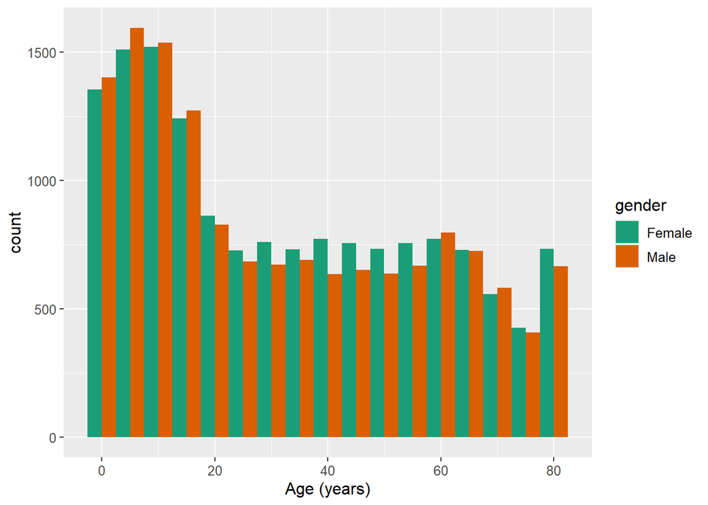

```r
ggplot(data = nhanes_data, aes(x = age, fill = gender)) +
  geom_histogram(binwidth = 5, position = "dodge") +
  scale_fill_brewer(palette = "Dark2") +
  labs(x = "Age (years)") +
  theme(text = element_text(size = 12))
```

Plot 2 - Histogram of Ethnicity by Gender

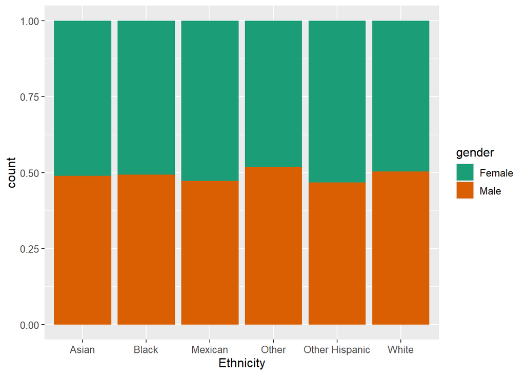

```r
ggplot(data = nhanes_data, aes(x = ethnicity_2, fill = gender)) +
  geom_bar(position = "fill") +
  scale_fill_brewer(palette = "Dark2") +
  labs(x = "Ethnicity") +
  theme(text = element_text(size = 12))
```

#### Combined Figures

Combine Plots

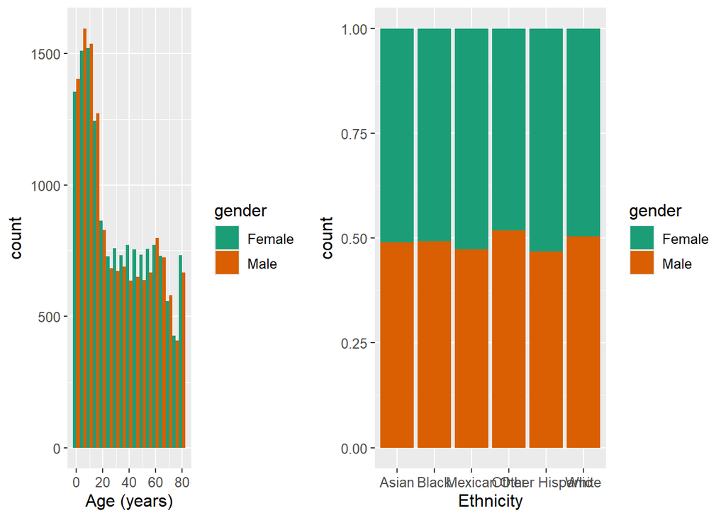

```r
#Create Plots
p1 <- ggplot(data = nhanes_data, aes(x = age, fill = gender)) +
  geom_histogram(binwidth = 5, position = "dodge") +
  scale_fill_brewer(palette = "Dark2") +
  labs(x = "Age (years)") +
  theme(text = element_text(size = 12))

p2 <- ggplot(data = nhanes_data, aes(x = ethnicity_2, fill = gender)) +
  geom_bar(position = "fill") +
  scale_fill_brewer(palette = "Dark2") +
  labs(x = "Ethnicity") +
  theme(text = element_text(size = 12))

# combine the plots with plot_grid
plot_grid(p1, p2,
           rel_widths = c(6, 8)
 )
```

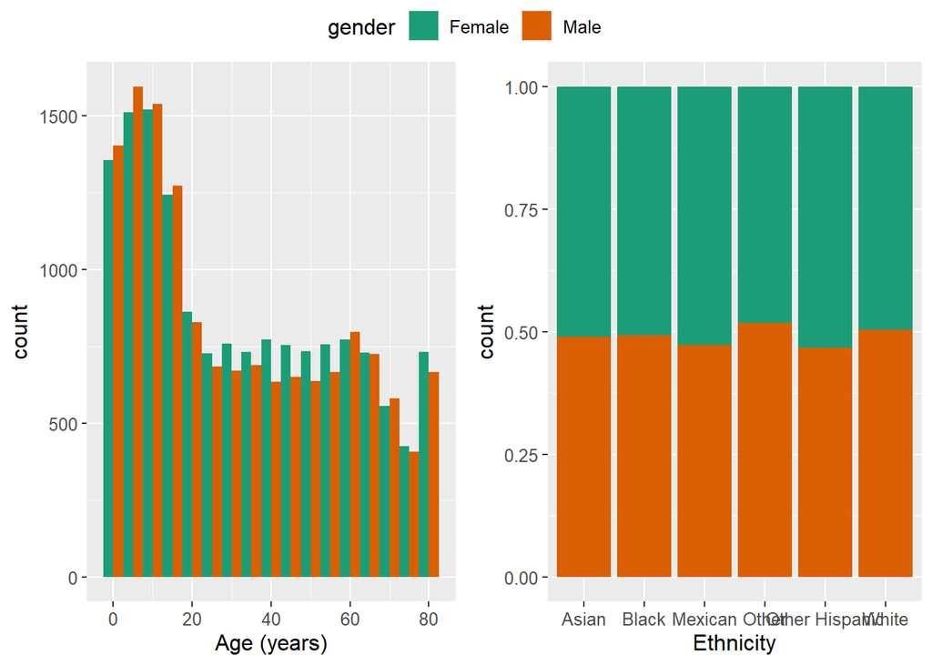

```r
# combine the plots with ggarrange
ggarrange(p1, p2, common.legend = TRUE, legend = "top")
```

Combining Plots with ggarrange looks better than combining with plot_grid because it creates a common legend, leaving more width for the plots themselves.

## Exercise 2

Plotting Age, Gender and Ethnicity_1 variables from NHANES

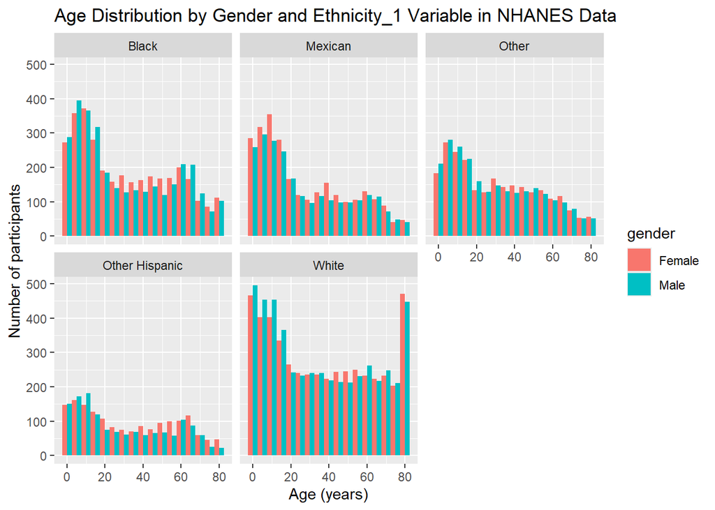

```r
plot_1 <- ggplot(nhanes_data, aes(x = age, fill = gender)) +
  geom_histogram(binwidth = 5, position = "dodge") +
  facet_wrap(~ ethnicity_1) +
  labs(
    title = "Age Distribution by Gender and Ethnicity_1 Variable in NHANES Data",
    x = "Age (years)",
    y = "Number of participants")
plot_1
```

Plotting Age, Gender and Ethnicity_2 variables from NHANES

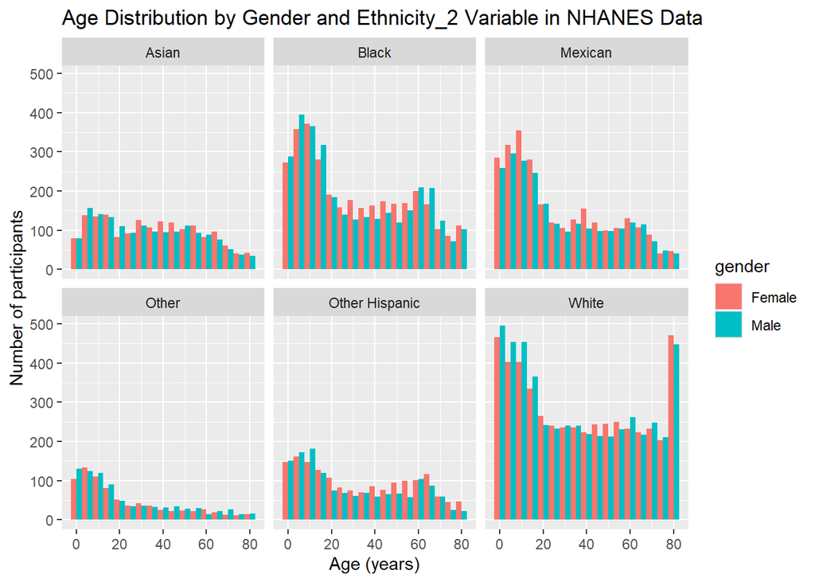

```r
plot_2 <- ggplot(nhanes_data, aes(x = age, fill = gender)) +
  geom_histogram(binwidth = 5, position = "dodge") +
  facet_wrap(~ ethnicity_2) +
  labs(
    title = "Age Distribution by Gender and Ethnicity_2 Variable in NHANES Data",
    x = "Age (years)",
    y = "Number of participants")
plot_2
```

Showing distribution and missing Values of Age, Gender and Ethnicity variables

```r
summary(nhanes_data[c("age", "gender", "ethnicity_1", "ethnicity_2")])
```

```
##       age              gender         ethnicity_1       ethnicity_2
##  Min.   : 0.00   Length   :29400   Length   :29400   Length   :29400
##  1st Qu.:10.00   N.unique :    2   N.unique :    5   N.unique :    6
##  Median :28.00   N.blank  :    0   N.blank  :    0   N.blank  :    0
##  Mean   :32.52   Min.nchar:    4   Min.nchar:    5   Min.nchar:    5
##  3rd Qu.:54.00   Max.nchar:    6   Max.nchar:   14   Max.nchar:   14
##  Max.   :80.00
```

The Ethnicity_2 Variable is more appropriate to keep because it provides more information and specificity on ethnicity in the study population (i.e., the “Asian” sub-population).

Saving the Two Plots

```r
ggsave(
  filename = here("figures", "plot1.png"),
  plot = plot_1,
  width = 8,
  height = 6
)

ggsave(
  filename = here("figures", "plot2.png"),
  plot = plot_2,
  width = 8,
  height = 6
)
```

##Exercise 3

The colleagues figure does not have a title, units for weight. It also doesn’t easily demonstrate any “key messages” about the overall effectiveness of the diet.

This chart could be improved by measuring how much each participants weight changes relatively compared to their baseline weight at week 0. That will provide more info on the diet’s overall effect/participant weight change trends.

Creating New Columns for new plot demonstrating weight change from baseline at Week0

```r
#importing data
diet_data <- import(here("data", "diet.csv"))

# Shows the structure of data
str(diet_data)
```

```
## 'data.frame':    340 obs. of  3 variables:
##  $ Week       : int  0 1 2 3 4 5 6 7 8 9 ...
##  $ Participant: int  1 1 1 1 1 1 1 1 1 1 ...
##  $ Weight     : num  95.9 94.2 93.6 93.1 91.2 ...
```

```r
#Creating new column for weight change from baseline at Week 0
diet_new <- diet_data %>%
  group_by(Participant) %>%
  mutate(
    baseline_weight = Weight[Week == 0],
    weight_change = Weight - baseline_weight
  )
# View new data
view(diet_new)
```

Creating new chart on diet data demonstrating weight change from baseline at Week0

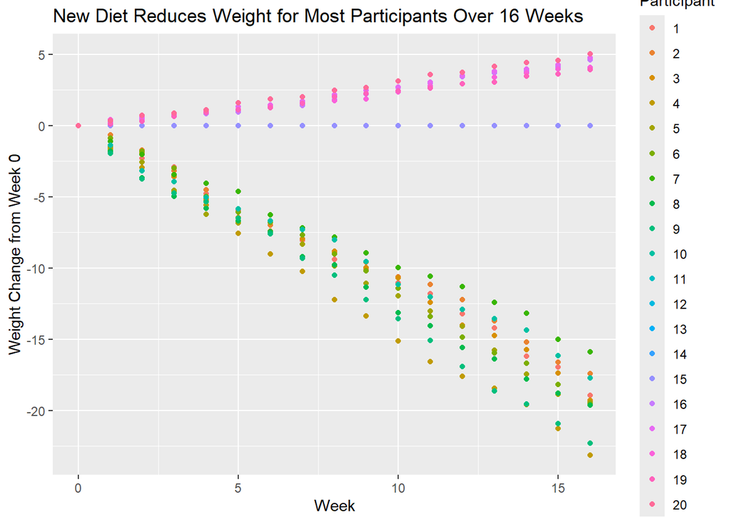

```r
ggplot(diet_new, aes(
  x = Week,
  y = weight_change,
  colour = factor(Participant)
)) +
  geom_point() +
    labs(
    title = "New Diet Reduces Weight for Most Participants Over 16 Weeks",
    x = "Week",
    y = "Weight Change from Week 0",
    colour = "Participant"
  )
```

##Exercise 4

Exploring relationships between age, gender and SPB

```r
nhanes_data <- nhanes_data %>%
  mutate(
    avg_sbp = rowMeans(
      select(., systolic_bp_1, systolic_bp_2, systolic_bp_3, systolic_bp_4),
      na.rm = TRUE
    ),
    avg_sbp = ifelse(is.nan(avg_sbp), NA, avg_sbp)
  )

# Shows the structure of updated data
str(nhanes_data)
```

```
## 'data.frame':    29400 obs. of  22 variables:
##  $ V1            : int  1 2 3 4 5 6 7 8 9 10 ...
##  $ patient_id    : num  73557 73558 73559 73560 73561 ...
##  $ bp_comment    : int  NA NA NA NA NA NA NA NA NA NA ...
##  $ systolic_bp_1 : int  122 156 140 108 136 160 NA 118 128 140 ...
##  $ diastolic_bp_1: int  72 62 90 38 86 84 NA 80 74 78 ...
##  $ systolic_bp_2 : int  114 160 140 102 134 158 NA 124 124 142 ...
##  $ diastolic_bp_2: int  76 80 76 34 88 82 NA 80 72 78 ...
##  $ systolic_bp_3 : int  102 156 146 104 142 154 NA 126 114 142 ...
##  $ diastolic_bp_3: int  74 42 80 38 86 80 NA 82 72 76 ...
##  $ systolic_bp_4 : int  NA NA NA NA NA NA NA NA NA NA ...
##  $ diastolic_bp_4: int  NA NA NA NA NA NA NA NA NA NA ...
##  $ wave_id       : int  2015 2015 2015 2015 2015 2015 2015 2015 2015 2015 ...
##  $ gender        : chr  "Male" "Male" "Male" "Male" ...
##  $ age           : int  69 54 72 9 73 56 0 61 56 65 ...
##  $ ethnicity_1   : chr  "Black" "White" "White" "White" ...
##  $ ethnicity_2   : chr  "Black" "White" "White" "White" ...
##  $ education     : chr  "High School" "High School" "Some college" NA ...
##  $ marital_status: chr  "Separated" "Married" "Married" NA ...
##  $ family_size   : chr  "3" "4" "2" "4" ...
##  $ family_income : chr  "$15,000 - $19,999" "$35,000 - $44,999" "$65,000 - $74,999" "$55,000 - $64,999" ...
##  $ age_cat       : chr  "60+" "40-59" "60+" "0-17" ...
##  $ avg_sbp       : Named num  113 157 142 105 137 ...
##   ..- attr(*, "names")= chr [1:29400] "1" "2" "3" "4" ...
```